# Assesment

Keyur Nandu

5/12/2020

Using devices such as Jawbone Up, Nike FuelBand, and Fitbit it is now possible to collect a large amount of data about personal activity relatively inexpensively. These type of devices are part of the quantified self movement – a group of enthusiasts who take measurements about themselves regularly to improve their health, to find patterns in their behavior, or because they are tech geeks. One thing that people regularly do is quantify how much of a particular activity they do, but they rarely quantify how well they do it. In this project, your goal will be to use data from accelerometers on the belt, forearm, arm, and dumbell of 6 participants. They were asked to perform barbell lifts correctly and incorrectly in 5 different ways. More information is available from the website here: http://web.archive.org/web/20161224072740/http:/groupware.les.inf.puc-rio.br/har (see the section on the Weight Lifting Exercise Dataset).

```r
library(caret)
library(ggplot2)
library(rpart)
library(randomForest)
library(dplyr)
```

Loadind the data set and exploring it!

```r
#along with importing data we are adding NA to blank cells of csv files
raw_train <- read.csv("data/pml-training.csv", na.strings=c("","NA"))
raw_test <- read.csv("data/pml-testing.csv", na.strings=c("","NA"))

head(raw_train)
```

```
##   X user_name raw_timestamp_part_1 raw_timestamp_part_2   cvtd_timestamp
## 1 1  carlitos           1323084231               788290 05/12/2011 11:23
## 2 2  carlitos           1323084231               808298 05/12/2011 11:23
## 3 3  carlitos           1323084231               820366 05/12/2011 11:23
## 4 4  carlitos           1323084232               120339 05/12/2011 11:23
## 5 5  carlitos           1323084232               196328 05/12/2011 11:23
## 6 6  carlitos           1323084232               304277 05/12/2011 11:23
##   new_window num_window roll_belt pitch_belt yaw_belt total_accel_belt
## 1         no         11      1.41       8.07    -94.4                3
## 2         no         11      1.41       8.07    -94.4                3
## 3         no         11      1.42       8.07    -94.4                3
## 4         no         12      1.48       8.05    -94.4                3
## 5         no         12      1.48       8.07    -94.4                3
## 6         no         12      1.45       8.06    -94.4                3
##   kurtosis_roll_belt kurtosis_picth_belt kurtosis_yaw_belt skewness_roll_belt
```

[output cut: 251 more lines]

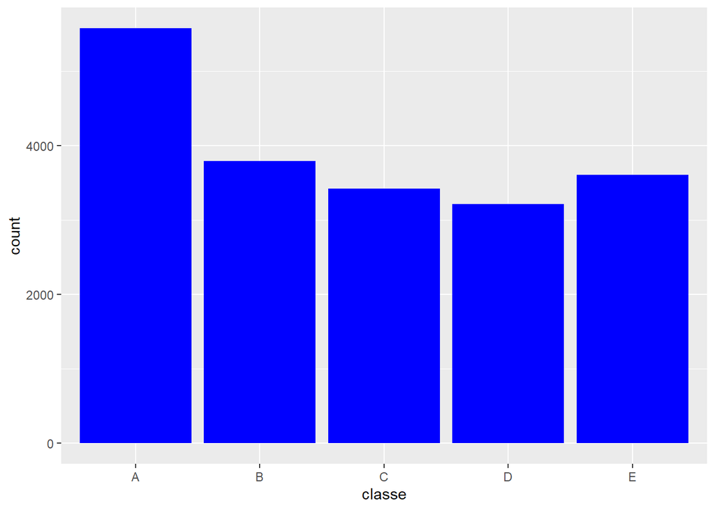

```r
raw_train %>% ggplot(aes(classe)) + geom_bar(stat = "count", fill = "blue")
```

As there are null values and many columns in the columns we need to do some data wrangling!

```r
# removing columns with NA greater than 50%
training <- raw_train[, which(colMeans(!is.na(raw_train)) > 0.5)]
testing <- raw_test[,which(colMeans(!is.na(raw_train))>0.5)]

#First seven columns of the dataset are not so useful we can remove them
sam <- training[,-c(1:7)]
testing <- testing[,-c(1:7)]

#creating data partion of training sample for modeling
intrain <- createDataPartition(y= sam$classe, p=0.7, list = FALSE)

sam_train <- sam[intrain,]
sam_test <- sam[-intrain,]
```

#Decision Tree

```r
model_dt <- rpart(classe ~ ., data = sam_train, method = "class")
pred_dt <- predict(model_dt,sam_test, type = "class")

confusionMatrix(table(pred_dt,sam_test$class))
```

```
## Confusion Matrix and Statistics
##
##
## pred_dt    A    B    C    D    E
##       A 1494  171   41  101   23
##       B   51  717  101   79   85
##       C   49  104  808  162  138
##       D   35   88   51  514   35
##       E   45   59   25  108  801
##
## Overall Statistics
##
##                Accuracy : 0.7364
##                  95% CI : (0.725, 0.7477)
##     No Information Rate : 0.2845
##     P-Value [Acc > NIR] : < 2.2e-16
##
##                   Kappa : 0.6654
##
##  Mcnemar's Test P-Value : < 2.2e-16
##
## Statistics by Class:
##
##                      Class: A Class: B Class: C Class: D Class: E
## Sensitivity            0.8925   0.6295   0.7875  0.53320   0.7403
## Specificity            0.9202   0.9334   0.9068  0.95753   0.9507
## Pos Pred Value         0.8164   0.6941   0.6408  0.71093   0.7717
## Neg Pred Value         0.9556   0.9130   0.9529  0.91282   0.9420
## Prevalence             0.2845   0.1935   0.1743  0.16381   0.1839
## Detection Rate         0.2539   0.1218   0.1373  0.08734   0.1361
## Detection Prevalence   0.3110   0.1755   0.2143  0.12285   0.1764
## Balanced Accuracy      0.9063   0.7815   0.8471  0.74536   0.8455
```

#Random Forest

```r
library(parallel)
library(doParallel)
cluster <- makeCluster(detectCores() - 1) # convention to leave 1 core for OS
registerDoParallel(cluster)

fitControl <- trainControl(method = "cv",
                           number = 5,
                           allowParallel = TRUE)



model_rf <- train(classe ~ ., method = "rf", data = sam_train, trControl =fitControl )

stopCluster(cluster)
registerDoSEQ()

pred_rf <- predict(model_rf,sam_test)

confusionMatrix(table(pred_rf,sam_test$class))
```

```
## Confusion Matrix and Statistics
##
##
## pred_rf    A    B    C    D    E
##       A 1672    4    0    0    0
##       B    2 1130   10    0    0
##       C    0    5 1016   15    4
##       D    0    0    0  949    3
##       E    0    0    0    0 1075
##
## Overall Statistics
##
##                Accuracy : 0.9927
##                  95% CI : (0.9902, 0.9947)
##     No Information Rate : 0.2845
##     P-Value [Acc > NIR] : < 2.2e-16
##
##                   Kappa : 0.9908
##
##  Mcnemar's Test P-Value : NA
##
## Statistics by Class:
##
##                      Class: A Class: B Class: C Class: D Class: E
## Sensitivity            0.9988   0.9921   0.9903   0.9844   0.9935
## Specificity            0.9991   0.9975   0.9951   0.9994   1.0000
## Pos Pred Value         0.9976   0.9895   0.9769   0.9968   1.0000
## Neg Pred Value         0.9995   0.9981   0.9979   0.9970   0.9985
## Prevalence             0.2845   0.1935   0.1743   0.1638   0.1839
## Detection Rate         0.2841   0.1920   0.1726   0.1613   0.1827
## Detection Prevalence   0.2848   0.1941   0.1767   0.1618   0.1827
## Balanced Accuracy      0.9989   0.9948   0.9927   0.9919   0.9968
```

```r
# This will give us the prediction of the 20 variables in testing dataset
list(predict(model_rf, testing))
```

```
## [[1]]
##  [1] B A B A A E D B A A B C B A E E A B B B
## Levels: A B C D E
```